# 297.101 Lecture JG6: Experiments

Author

Jonathan Godfrey a.j.godfrey@massey.ac.nz

[Watch the latest recording of this lecture](https://r-resources.massey.ac.nz/videos/SDS6.mp4)

## What is an experiment?

An experiment is a data collection exercise that is planned so that the impact of changes of input factors on a response variable of interest can be compared. It is intentional that a cause and effect link between the input and the outcome be established.

Experiments are conducted under controlled conditions, well as much as is possible anyway.

We like experiments because they are repeatable.

Scientific discovery is often by way of experimentation.

### Some examples

Each of the following publications is a result of a scientist having a collaboration with a statistician (me). In most cases, the collaboration arose because something went wrong with the planning of the experiment, or at least the scientist couldn’t perform the statistical analyses that arose from their well-laid plans. It would certainly be better to see the scientists before data is collected.

- M. Bulgarella, M. Morgan-Richards, A.J.R. Godfrey, B.J. Sinclair, and S.A. Trewick. Elevational variation in adult body size and growth rate but not in metabolic rate in the tree weta hemideina crassidens. Journal of Insect Physiology, 75:30–38, Apr 2015.
- E. Effah, D.P. Barrett, P.G. Peterson, A.J.R. Godfrey, M.A. Potter, J.K. Holopainen, and A. Clavijo McCormick. An invasive plant changes its scent along an invasion gradient when paired with different competitors. Plants, 9(2):283, 2020.
- S.F. Forsyth, W.G. Guilford, S.J. Haslett, and J. Godfrey. Endoscopy of the gastoduodenal mucosa after carprofen, meloxicam and ketoprofen administration in dogs. Journal of Small Animal Practice, 39:421–424, 1998.
- L.A. Fullard, E.C.P. Breard, C.E. Davies, A.J.R. Godfrey, M. Fukuoka, A. Wade, J. Dufek, and G. Lube. The dynamics of granular flow from a silo with two symmetric openings. Proceedings of the Royal Society A: Mathematical, Physical and Engineering Sciences, 475(2221):20180462, 2019.
- L.A. Fullard, A.J.R. Godfrey, M.F. Manaf, C.E. Davies, A. Cliff, and M. Fukuoka. Mixing experiments in 3d-printed silos; the role of wall friction and flow correcting inserts. Advanced Powder Technology, 31(5):1915–1923, 2020.
- R. Kant, S.A. Trewick, W.R.M. Sandanayaka, A.J.R. Godfrey, and M.A. Minor. Effects of multiple mating on reproductive fitness of male and female diaeretiella rapae (hymenoptera: Aphidiidae). Entomologia Experimentalis et Applicata, 145:215–221, 2012.
- N. Kells, N.J. Beausoleil, A.J.R. Godfrey, K.E. Littlewood, N. Ward, and C.B. Johnson. Effect of analgesic strategies on pain behaviour associated with combined ring castration and hot iron tail docking in merino lambs. Applied Animal Behaviour Science, 222:104914, 2020.
- Y-M. Leung, N.J. Cave, A. Heiser, P.J.B. Edwards, A.J.R. Godfrey, and T. Wester. Metabolic and immunological effects of intermittent fasting on a ketogenic diet containing medium-chain triglycerides in healthy dogs. Frontiers in Veterinary Science, 6:480, 2020.
- N. A Minards, S.A. Trewick, A.J.R. Godfrey, and M. Morgan-Richards. Convergent local adaptation in size and growth rate but not metabolic rate in a pair of parapatric orthoptera species. Biological Journal of the Linnean Society, 113(1):123–135, 2014.
- J. Pierce, S. Legg, A.J.R. Godfrey, and E. Kawabata. The effects of introducing electric adjustable height desks in an office setting on workplace physical activity levels — a randomised control field trial. Work, 62(1):139–150, 2019.

## Planning an experiment

We often need to document what we intend to do when we carry out an experiment. In some situations this is called a **protocol** but from a statistical point of view we call it an **experimental design**.

We worry about three major statistical concerns…

### Local control

We cannot always use raw material for our experiments that is totally consistent (homogeneous) so we ensure we group raw material or at least measure the potentially influential factors that might determine something about our outcome of interest.

Once we understand our raw material, we can ensure that we “group” similar items together and record which group each item has joined. A common strategy for this is called “blocking”.

### Randomisation

Just like other data collection efforts, our results should be free from any known biases, but we must still protect ourselves from the unknown biases that could exist.

This is most easily done by randomising the particular items that will receive which combination of the input factors.

N.B. Randomisation does not reduce variability. It ensures variability is measured properly (without bias).

### Replication

A key part of understanding the impact of our inputs is to know what could happen just by chance alone. If we only ever see a single result, we have no idea of what is common variation (noise) and what is a direct result of the input factors (signal).

It is common to use more than one item in an experiment for any combination of the inputs. This replication also helps us avoid problems if for some reason we lose part of our experiment.

N.B. Replication helps reduce the standard error of our estimates.

## Gauging the impact of an intervention

Option 1: get the measurements on a group of people who did get the intervention and a measurements from a second group that did not.

Option 2: Get a group of people together, measure them before the intervention, and then after the intervention.

Option 3: Option 2 with a second group being given a placebo (fake intervention).

Option 1 is not an experiment; it is an **observational study**. Subjects were not randomly allocated the intervention, or at least we can’t be sure it is free from biases which randomisation protects us from. We hope the subjects in the two groups form equivalent sets.

Option 2 is an experiment. All measurements can be converted to a difference (After - Before) and if we are convinced this difference is nonzero, then the intervention is said to have an impact.

Option 3 is a better experiment because as well as being able to understand the difference for those who did get the active intervention, we can compare that difference to a passive placebo effect.

Options 2 and 3 use pairing of data to remove the impact of person to person variation. They assume that each person has only changed because of the intervention.

### Control

In Lecture JG3, I mentioned an experiment that recorded the amount of lesion damage in dogs given one of four treatments. One of the treatments was “Gelatine” which was a placebo. In addition to the administration of gelatine tablets, these dogs were subjected to the investigation of their digestive tract with the endoscope; this action may in itself be a cause of lesion damage. We may also need to know if lesion damage is normal in dogs that are not subjected to endoscopy but how can we tell?

A placebo is used in experiments to act as a control so that we can ensure that we can better describe the impact of the active treatments we wish to learn more about.

A well-known or the status quo treatment might also form a control, so that a new treatment option can be compared to the existing practice.

Most statistical experiments are therefore **comparative experiments**.

## Randomised complete block design

Splitting a set of heterogeneous experimental units into more homogeneous sets (called **blocks**) is one commonly used form of local control.

A Randomised Complete Block design then assigns each different treatment to an experimental unit in every block. It is complete because each block has every treatment and every treatment is in every block. This leads (fairly naturally) to a two-way table of results, but sometimes also matches the physical constraints of the actual experiment. For example:

- ten trays of seedlings are planted; each tray can fit six plants, one of each of six cultivars of interest. When it comes time to put the trays into a greenhouse, there is a chance that the positioning of the different trays could alter the time for seeds to germinate and/or for foliage to develop.
- 32 overweight dogs are to be fed one of four diets that are hoped will maintain health but will also see them lose weight over time. It is better to arrange them into eight groups of four (roughly similar) dogs and randomly allocate diets within each group to ensure we have protected against some sources of bias.

### A simplified analysis of an RCB example

In the analysis of the penicillin data below, the **block** is the `blend`, while the treatment of interest is called `treat`. The `yield` is the thing we want to know more about. The data comes from a famous book on experimental design (Box, Hunter, and Hunter).

```r
library(tidyverse)
data(penicillin.data, package = "BHH2")
```

Looking at the raw data that is of interest, we plot the `yield` for each `treat`ment.

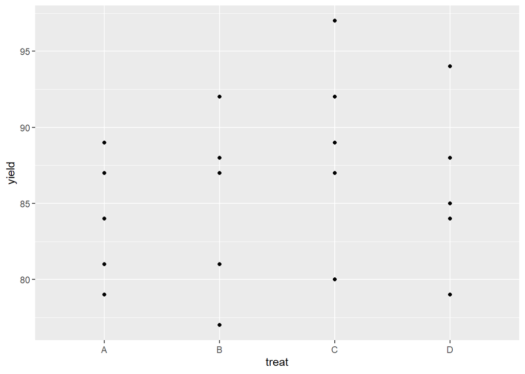

```r
ggplot(penicillin.data, aes(x = treat, y = yield)) + geom_point()
```

It is hard to see if the treatment really has much impact to get excited about. But, if we adjust the observations to remove the differences among the blends…

```r
penicillin.data |>
    group_by(blend) |>
    mutate(BlockMean = mean(yield), AdjustedYield = yield - BlockMean + mean(penicillin.data$yield)) ->
    Penicillin
Penicillin |>
    kable()
```

| blend | run | treat | yield | BlockMean | AdjustedYield |
| --- | --- | --- | --- | --- | --- |
| B1 | 1 | A | 89 | 92 | 83 |
| B2 | 4 | A | 84 | 83 | 87 |
| B3 | 2 | A | 81 | 85 | 82 |
| B4 | 1 | A | 87 | 88 | 85 |
| B5 | 3 | A | 79 | 82 | 83 |
| B1 | 3 | B | 88 | 92 | 82 |
| B2 | 2 | B | 77 | 83 | 80 |
| B3 | 1 | B | 87 | 85 | 88 |
| B4 | 3 | B | 92 | 88 | 90 |
| B5 | 4 | B | 81 | 82 | 85 |
| B1 | 2 | C | 97 | 92 | 91 |
| B2 | 3 | C | 92 | 83 | 95 |
| B3 | 4 | C | 87 | 85 | 88 |
| B4 | 2 | C | 89 | 88 | 87 |
| B5 | 1 | C | 80 | 82 | 84 |
| B1 | 4 | D | 94 | 92 | 88 |
| B2 | 1 | D | 79 | 83 | 82 |
| B3 | 3 | D | 85 | 85 | 86 |
| B4 | 4 | D | 84 | 88 | 82 |
| B5 | 2 | D | 88 | 82 | 92 |

then we can see the differences among the treatments more clearly…

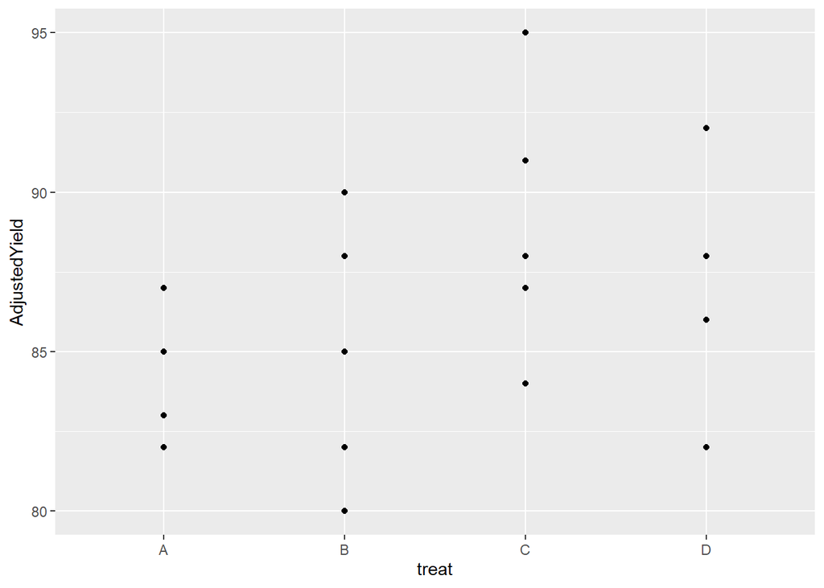

```r
ggplot(Penicillin, aes(x = treat, y = AdjustedYield)) + geom_point()
```

So, knowing that the `blend` matters, we find that after adjusting for its impact we can more easily see the treatment differences.

## Some interesting designs

### Split plot experiment

- Two treatment factors of interest.
- One treatment factor gets applied to large areas which then get “split” up;
- the second treatment factor gets applied at the level of smaller areas.

Examples:

- agriculture: lots of situations where something like fertiliser is applied to large tracts of land and a manual process is used on smaller areas within the large areas.
- batch processed production: one treatment is applied to the batch and then a second factor of interest gets used once the batch is split into more manageable units such as bottles. This is common in food processeing experiments.

Main Plots for the four replicates of three levels of Factor A:

| A3 | A1 | A1 | A2 |
| --- | --- | --- | --- |
| A1 | A3 | A3 | A1 |
| A2 | A2 | A2 | A3 |

Each of those areas then gets divided up into four subplots of the same shape, but a different arrangement for the four levels of Factor B is chosen in each of the above 12 zones where Factor A was applied. This makes a total of 48 observations. The first third is as follows:

| A3:B1 | A3:B3 | A1:B3 | A1:B1 | A1:B4 | A1:B3 | A2:B4 | A2:B3 |
| --- | --- | --- | --- | --- | --- | --- | --- |
| A3:B2 | A3:B4 | A1:B2 | A1:B4 | A1:B2 | A1:B12 | A2:B1 | A2:B1 |

The other two rows of main plots need to be added here to complete the full description; but it will also have two-by-two sets of B1 to B4 with a const A1, A2, or A3.

Randomisation is done for Factor A, then separately for Factor B.

### Strip block experiment

- Two treatment factors need testing in combination but they each get applied to a number of experimental units at the same time.
- experimental units are arranged in a rectanbular array.
- one treatment factor is applied to rows of this array;
- the other treatment is applied to columns of the array

Example:

Imagine a field experiment growing grass for sports fields. Each testing field is split into 6 rows and 6 columns so that the tractor can spread one of the 3 fertilisers under examination in the columns, and use one of the 3 mowers under investigation in the rows.

| F3:M1 | F1:M1 | F2:M1 | F1:M1 | F3:M1 | F2:M1 |
| --- | --- | --- | --- | --- | --- |
| F3:M3 | F1:M3 | F2:M3 | F1:M3 | F3:M3 | F2:M3 |
| F3:M2 | F1:M2 | F2:M2 | F1:M2 | F3:M2 | F2:M2 |
| F3:M2 | F1:M2 | F2:M2 | F1:M2 | F3:M2 | F2:M2 |
| F3:M1 | F1:M1 | F2:M1 | F1:M1 | F3:M1 | F2:M1 |
| F3:M3 | F1:M3 | F2:M3 | F1:M3 | F3:M3 | F2:M3 |

## What makes some designs harder to analyse?

The more protection against mishaps and biases we build into our planning, the more complicated our analysis needs to be. The most common reason for complication in the analysis is the way randomisation has been applied when assigning treatment combinations to experimental units.

The great thing about planning an experiment is that we can work out how to analyse the data before it is collected. We don’t know what the numbers in tabulated findings will look like, or the specifics of the graphs that describe those findings, but we know what shape and form these tables and graphs will take.

We can develop our analysis document using random numbers while we wait for the real data; we’ll then have the outcome of our experiment within seconds of entering the data into the waiting files.

[interactive chart not shown]